# Medical cost prediction revisited

Insurance companies need to predict the annual medical cost of a insurance policy holder.

- Target: **annual medical cost**
- Predictors:
  - age, gender, bmi, number of children, smoker/non-smoke, region

Let us load the dataset.

```python
import pandas as pd
med_cost = pd.read_csv("Data/medical_costs.csv")
med_cost.head()
```

|  | age | sex | bmi | children | smoker | region | charges |
| --- | --- | --- | --- | --- | --- | --- | --- |
| 0 | 19 | female | 27.900 | 0 | yes | southwest | 16884.92400 |
| 1 | 18 | male | 33.770 | 1 | no | southeast | 1725.55230 |
| 2 | 28 | male | 33.000 | 3 | no | southeast | 4449.46200 |
| 3 | 33 | male | 22.705 | 0 | no | northwest | 21984.47061 |
| 4 | 32 | male | 28.880 | 0 | no | northwest | 3866.85520 |

Let's perform **one-hot encoding** for **sex**, **smoker**, **region**.

```python
med_cost_encoded = pd.get_dummies(med_cost, drop_first=True,dtype=int)
med_cost_encoded.head()
```

|  | age | bmi | children | charges | sex_male | smoker_yes | region_northwest | region_southeast | region_southwest |
| --- | --- | --- | --- | --- | --- | --- | --- | --- | --- |
| 0 | 19 | 27.900 | 0 | 16884.92400 | 0 | 1 | 0 | 0 | 1 |
| 1 | 18 | 33.770 | 1 | 1725.55230 | 1 | 0 | 0 | 1 | 0 |
| 2 | 28 | 33.000 | 3 | 4449.46200 | 1 | 0 | 0 | 1 | 0 |
| 3 | 33 | 22.705 | 0 | 21984.47061 | 1 | 0 | 1 | 0 | 0 |
| 4 | 32 | 28.880 | 0 | 3866.85520 | 1 | 0 | 1 | 0 | 0 |

Let's seperate the feature variables from the target and perform train-test split

```python
X = med_cost_encoded.drop('charges',axis=1)
y = med_cost_encoded['charges']

from sklearn.model_selection import train_test_split
X_train,X_test,y_train,y_test = train_test_split(X,y,test_size=0.2,random_state=42)
```

## Linear Regression

Let's create a linear regression on all varaibles. We will:

- Fit the model on the training data
- Predict on the test data

```python
from sklearn.linear_model import LinearRegression
model = LinearRegression()
model.fit(X_train,y_train)

y_pred = model.predict(X_test)
```

Now we will calculate the (root) mean squared error and the $R^2$ score

```python
from sklearn.metrics import mean_squared_error, r2_score
import math
mse = mean_squared_error(y_test,y_pred)
rmse = math.sqrt(mse)

r2 = r2_score(y_test,y_pred)

print(rmse,r2)
```

```
5956.342894363585 0.8069287081198013
```

## KNN for Regression

We need the `KNeighborsRegressor()` function from `sklearn.neighbors` to create a KNN model for regression. Recall that we need to specify the number of neighbors.

We will fit the model on the training data and predict on the test data.

```python
from sklearn.neighbors import KNeighborsRegressor

knn = KNeighborsRegressor(n_neighbors=200)
knn.fit(X_train, y_train)
y_pred = knn.predict(X_test)
```

Let's again compute the RMSE and $R^2$ score.

```python
mse = mean_squared_error(y_test,y_pred)
rmse = math.sqrt(mse)
r2 = r2_score(y_test,y_pred)
print(rmse,r2)
```

```
12777.806550489011 0.1114723691230024
```

## Random Forest for Regression

We can use the `RandomForestRegressor()` to create a random forest model for regression. The function is included in the module `ensemble` of `sklearn`.

```python
from sklearn.ensemble import RandomForestRegressor

rf = RandomForestRegressor(n_estimators=200, random_state=42)
rf.fit(X_train, y_train)
y_pred = rf.predict(X_test)
```

Note that `RandomForestRegressor()` has similar arguments to `RandomForestClassifier()`. In the above, most arguments are set to their default value. See the [documentation of RandomForestRegressor](https://scikit-learn.org/dev/modules/generated/sklearn.ensemble.RandomForestRegressor.html) for details.

Now evaluate the performance on the test data.

```python
mse = mean_squared_error(y_test,y_pred)
rmse = math.sqrt(mse)

r2 = r2_score(y_test,y_pred)

print(rmse,r2)
```

```
4664.686755872737 0.8815859348971048
```

### XGBOOST for Regression

XGBoost stands for Extreme Gradient Boosting and is based on the gradient boosting framework.

- Builds decision trees iteratively, with each tree correcting the residuals (errors) of previous trees.
- Highly optimized for performance with features like parallel computation, tree pruning (max depth), and out-of-core computing for large datasets.

XGBOOST is not part of `sklearn`. Use the following common to install the library (only need to be installed once on your computer).

```python
!pip install xgboost
```

```
Downloading xgboost-2.1.2-py3-none-macosx_10_15_x86_64.macosx_11_0_x86_64.macosx_12_0_x86_64.whl (2.1 MB)
   ━━━━━━━━━━━━━━━━━━━━━━━━━━━━━━━━━━━━━━━━ 2.1/2.1 MB 1.6 MB/s eta 0:00:0000:0100:01
```

Now we can import the `xgboost` library and use it to create a XGBOOST model.

```python
from xgboost import XGBRegressor, plot_importance

xgb_model = XGBRegressor(n_estimators=500, learning_rate=0.1, max_depth=3, random_state=42)

# Train the model
xgb_model.fit(X_train, y_train)

# Make predictions on the test set
y_pred = xgb_model.predict(X_test)

# Performance evaluation
mse = mean_squared_error(y_test,y_pred)
rmse = math.sqrt(mse)
r2 = r2_score(y_test,y_pred)

print(rmse,r2)
```

```
4563.253071734933 0.8866797745948622
```

In the above, we have ommited most of the arguments, effectively setting them to the default values. See the [documentation of XGBOOST](https://xgboost.readthedocs.io/en/stable/parameter.html) for the full list of arguments.

Arguments to this method inculdes:

- The trained model
- The type of importance:
  - `gain`: Average improvement in model performance brought by a feature
  - `weight`: Number of times a feature is used in splits
  - `cover`: Average number of data samples (instances) impacted by splits that involve a particular feature

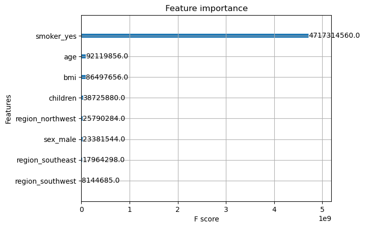

```python
import matplotlib.pyplot as plt

plot_importance(xgb_model,importance_type='gain')
plt.show()
```